# Reproducible Research: Project 1

Ryan Honomichl

August 14, 2016

## Load libraries; loading and preprocessing the data

```r
library(dplyr)
library(ggplot2)
library(mice)
```

```r
if(dir.exists("C:/Users/Ryan Honomichl/Dropbox/Coursera/5_Reproducible_Research/Week_2/project")) {

  setwd("C:/Users/Ryan Honomichl/Dropbox/Coursera/5_Reproducible_Research/Week_2/project")

}else{

  dir.create("C:/Users/Ryan Honomichl/Dropbox/Coursera/5_Reproducible_Research/Week_2/project")

  setwd("C:/Users/Ryan Honomichl/Dropbox/Coursera/5_Reproducible_Research/Week_2/project")
}

fileUrl <- "https://d396qusza40orc.cloudfront.net/repdata%2Fdata%2Factivity.zip"

download.file(fileUrl,destfile="./Dataset.zip")

unzip(zipfile="Dataset.zip")

activity.raw <- read.csv("./activity.csv", header=TRUE, sep=",")
```

### Check structure of data frame

```r
str(activity.raw)
```

```
## 'data.frame':    17568 obs. of  3 variables:
##  $ steps   : int  NA NA NA NA NA NA NA NA NA NA ...
##  $ date    : Factor w/ 61 levels "2012-10-01","2012-10-02",..: 1 1 1 1 1 1 1 1 1 1 ...
##  $ interval: int  0 5 10 15 20 25 30 35 40 45 ...
```

NOTE: date as factor

```r
activity.raw$date <- as.Date(activity.raw$date, "%Y-%m-%d")
```

```r
str(activity.raw)
```

```
## 'data.frame':    17568 obs. of  3 variables:
##  $ steps   : int  NA NA NA NA NA NA NA NA NA NA ...
##  $ date    : Date, format: "2012-10-01" "2012-10-01" ...
##  $ interval: int  0 5 10 15 20 25 30 35 40 45 ...
```

Note: Now date is a date variable

## Calculate the total number of steps taken per day (ignoring NAs)

```r
steps.sum <- activity.raw %>%
  filter(!is.na(steps)) %>%
  group_by(date) %>%
  summarize(TotalSteps=sum(steps))

print(steps.sum)
```

```
## # A tibble: 53 x 2
##          date TotalSteps
##        <date>      <int>
## 1  2012-10-02        126
## 2  2012-10-03      11352
## 3  2012-10-04      12116
## 4  2012-10-05      13294
## 5  2012-10-06      15420
## 6  2012-10-07      11015
## 7  2012-10-09      12811
## 8  2012-10-10       9900
## 9  2012-10-11      10304
## 10 2012-10-12      17382
## # ... with 43 more rows
```

## Make a histogram of the total number of steps taken each day

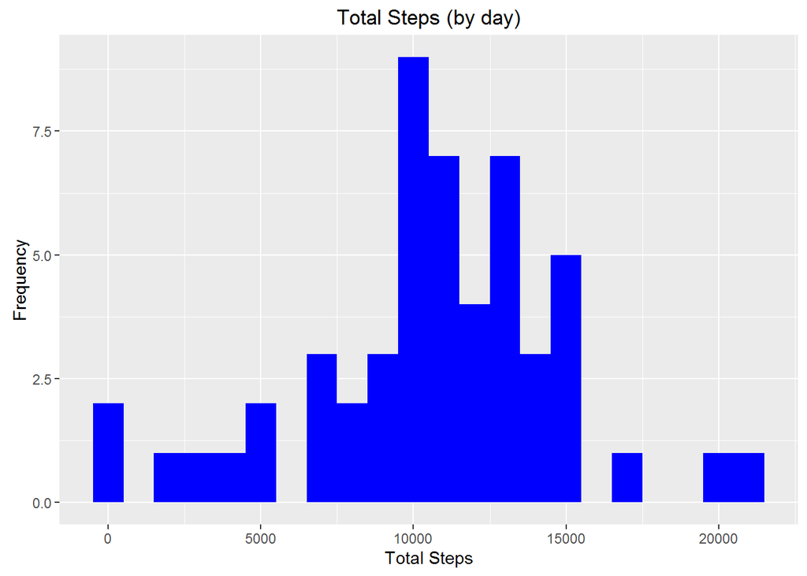

```r
s <- ggplot(steps.sum, aes(x = TotalSteps))

s + geom_histogram(fill = "blue",binwidth = 1000) +   labs(title = "Total Steps (by day)", x = "Total Steps",
  y = "Frequency")
```

## Calculate and report the mean and median of the total number of steps taken per day

```r
mean(steps.sum$TotalSteps)
```

```
## [1] 10766.19
```

```r
median(steps.sum$TotalSteps)
```

```
## [1] 10765
```

## Make a time series plot (i.e. type = “l”) of the 5-minute interval (x-axis) and the average number of steps taken, averaged across all days (y-axis)

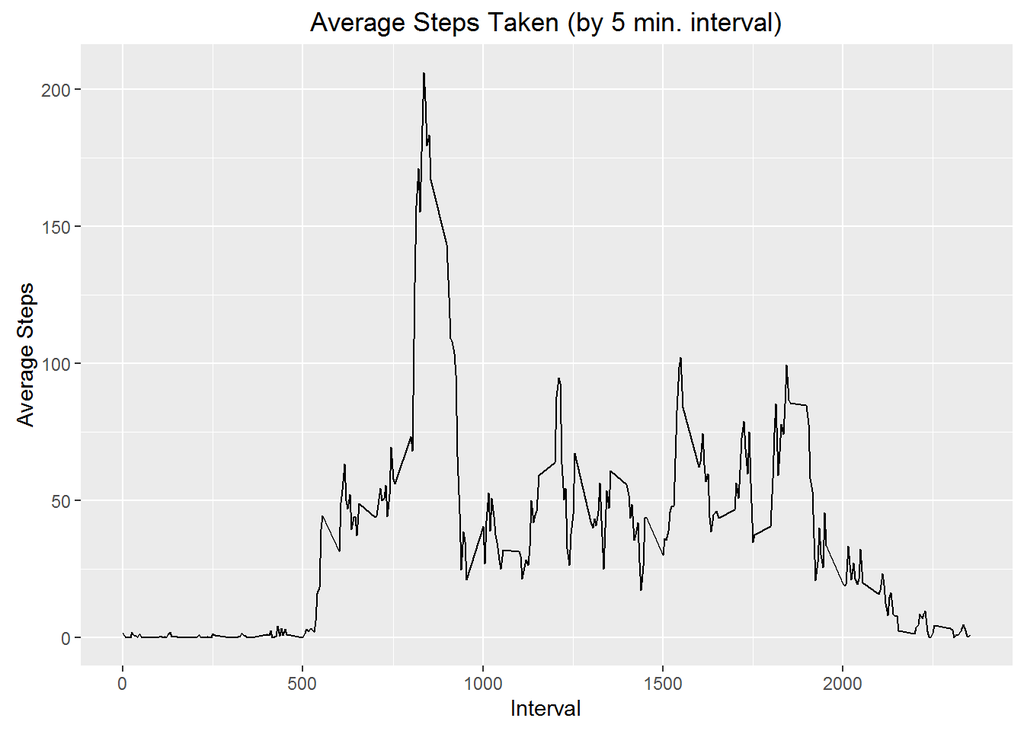

```r
act.no.na <- na.omit(activity.raw)

fivemin.int <- act.no.na %>%
  group_by(interval) %>%
  summarize(aver.steps=mean(steps))

s2 <- ggplot(fivemin.int, aes(x = interval, y = aver.steps))

s2 + geom_line() + labs(title = "Average Steps Taken (by 5 min. interval)", x = "Interval", y = "Average Steps")
```

## Which 5-minute interval, on average across all the days in the dataset, contains the maximum number of steps?

```r
max_interv <- fivemin.int[which.max(fivemin.int$steps),1]
fivemin.int$interval[which.max(fivemin.int$aver.steps)]
```

```
## [1] 835
```

## Imputing missing values: examine the number of missing data on the steps variable

```r
md.pattern(activity.raw)
```

```
##       date interval steps
## 15264    1        1     1    0
##  2304    1        1     0    1
##          0        0  2304 2304
```

NOTE: There are 15264 complete observations, 2304 observations with missing steps data

## Create a new dataset that is equal to the original dataset but with the missing data filled in.

```r
imputed.data <- activity.raw

for (i in 1:nrow(imputed.data)) {
  if (is.na(imputed.data$steps[i])) {
    # Find the index value for when the interval matches the average
    temp.d <- which(imputed.data$interval[i] == fivemin.int$interval)
    # Assign the value to replace the NA
    imputed.data$steps[i] <- fivemin.int[temp.d,]$aver.steps
  }
}
```

#### Calculate and report the mean and median total number of steps taken per day.

#### Do these values differ from the estimates from the first part of the assignment? What is the

#### impact of imputing missing data on the estimates of the total daily number of steps?

```r
steps.sum.imp <- imputed.data %>%
  group_by(date) %>%
  summarize(TotalSteps=sum(steps))

mean(steps.sum.imp$TotalSteps)
```

```
## [1] 10766.19
```

```r
median(steps.sum.imp$TotalSteps)
```

```
## [1] 10766.19
```

NOTE: mean is unchanged, but median is slightly changed and is now equal to the mean.

## Make a histogram of the total number of steps taken each day

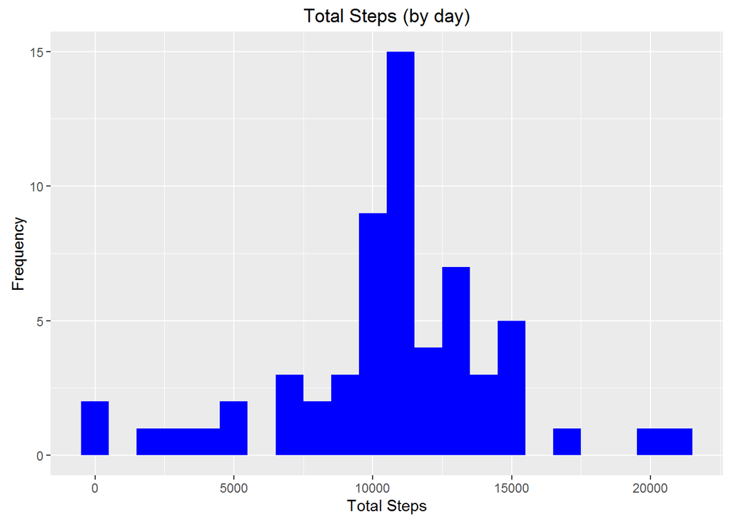

```r
s3 <- ggplot(steps.sum.imp, aes(x = TotalSteps))

s3 + geom_histogram(fill = "blue",binwidth = 1000) +   labs(title = "Total Steps (by day)", x = "Total Steps", y = "Frequency")
```

## Create a new factor variable in the dataset with two levels - “weekday” and “weekend” indicating whether

## a given date is a weekday or weekend day.

```r
imputed.data$day <- weekdays(imputed.data$date)

imputed.data$daytype[imputed.data$day %in% c("Monday", "Tuesday", "Wednesday", "Thursday", "Friday")] <- "weekday"

imputed.data$daytype[imputed.data$day %in% c("Saturday", "Sunday")] <- "weekend"

imputed.data$daytype <- as.factor(imputed.data$daytype)
```

#### Create a new factor variable in the dataset with two levels - “weekday” and “weekend” indicating whether

#### a given date is a weekday or weekend day.

```r
imputed.data$day <- weekdays(imputed.data$date)

imputed.data$daytype[imputed.data$day %in% c("Monday", "Tuesday", "Wednesday", "Thursday", "Friday")] <- "weekday"

imputed.data$daytype[imputed.data$day %in% c("Saturday", "Sunday")] <- "weekend"

imputed.data$daytype <- as.factor(imputed.data$daytype)
```

## Make a panel plot containing a time series plot (i.e. type = “l”) of the 5-minute interval (x-axis)

## and the average number of steps taken, averaged across all weekday days or weekend days (y-axis).

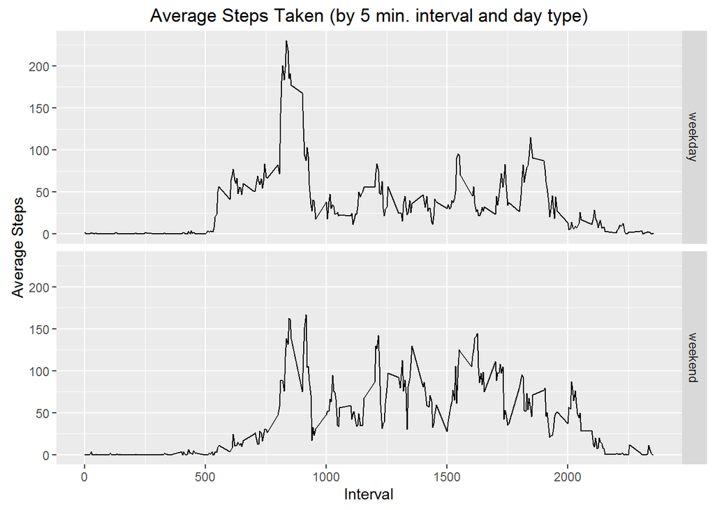

```r
fivemin.int.imp <- imputed.data %>%
  group_by(daytype, interval)%>%
  summarize(aver.steps=mean(steps))

s4 <- ggplot(fivemin.int.imp, aes(x = interval, y = aver.steps))

s4 + geom_line() + facet_grid(daytype ~ .) + labs(title = "Average Steps Taken (by 5 min. interval and day type)",
    x = "Interval", y = "Average Steps")
```